# Window Functions And Convolution/Multiplication Duality

## Chris Tralie

Forward DFT

## $X[k] = \sum_{n=0}^{N-1} x[n] e^{-i 2 \pi \frac{k}{N} n}$

Inverse DFT

## $x[n] = \frac{1}{N}\sum_{k=0}^{N-1} X[k] e^{i 2 \pi \frac{k}{N} n}$

Because the formulas for the forward and inverse DFT are so similar, we have the following two "dual properties" of convolution and multiplication:

- Convolution in the time domain leads to multiplication in the frequency domain
- Multiplication in the time domain leads to convolution in the frequency domain

We're going to examine the latter to help us understand the frequency properties of [window functions](https://ursinus-cs472a-s2021.github.io/Modules/Module11/Video1) that we use when doing the Short-Time Fourier Transform, since we multiply by windows in the time domain

```python
import numpy as np
import matplotlib.pyplot as plt
import IPython.display as ipd
from scipy.signal import fftconvolve
import librosa

def plot_dft_window(x, win_fn, sr):
    ylims = [1e-2, 1e4]
    X = np.fft.fft(x)
    nfreqs = int(len(x)/2) # Only plot the first half of the
    # frequencies since the second half is the mirror image_on
    X = X[0:nfreqs]
    freqs = np.arange(nfreqs)*sr/len(x)


    plt.figure(figsize=(10, 8))
    plt.subplot(321)
    plt.plot(x)
    plt.title("x")
    plt.subplot(322)
    plt.plot(freqs, np.abs(X))
    plt.yscale('log')
    ipd.Audio(x, rate=sr)
    plt.xlim([0, 3000])
    plt.ylim(ylims)
    plt.xlabel("Frequency (hz)")
    plt.title("|FFT(x)|")

    N2 = int(len(x)/2)
    N3 = int(len(x)/4)
    win = np.zeros(N)
    win[N3:N3+N2] = win_fn(N2)
    plt.subplot(323)
    plt.plot(win)
    plt.title("Window")
    W = np.fft.fft(win)
    nfreqs = int(len(win)/2) # Only plot the first half of the
    # frequencies since the second half is the mirror image_on
    W = W[0:nfreqs]
    freqs = np.arange(nfreqs)*sr/len(win)
    plt.subplot(324)
    plt.plot(freqs, np.abs(W))
    plt.yscale("log")
    plt.xlim([0, 3000])
    plt.ylim([1e-12, 1e4])
    plt.title("|FFT(win)|")
    plt.xlabel("Frequency (hz)")



    y = x*win
    plt.subplot(325)
    plt.plot(y)
    plt.title("x times win")
    Y = np.fft.fft(y)
    nfreqs = int(len(y)/2) # Only plot the first half of the
    # frequencies since the second half is the mirror image_on
    Y = Y[0:nfreqs]
    freqs = np.arange(nfreqs)*sr/len(y)
    plt.subplot(326)
    plt.plot(freqs, np.abs(Y))
    plt.yscale("log")
    plt.ylim(ylims)
    plt.xlim([0, 3000])
    plt.title("|FFT(x times win)|")
    plt.xlabel("Frequency (hz)")
    plt.tight_layout()
    return y
```

```python
def sin_window(N):
    """
    Create the sine window sin(pi*n/N)

    Parameters
    ----------
    N: int
        Length of window

    Returns
    -------
    ndarray(N): Samples of the window
    """
    return np.sin(np.pi*np.arange(N)/N)

def hann_window(N):
    """
    Create the Hann window 0.5*(1-cos(2pi*n/N))

    Parameters
    ----------
    N: int
        Length of window

    Returns
    -------
    ndarray(N): Samples of the window
    """
    return 0.5*(1 - np.cos(2*np.pi*np.arange(N)/N))


def blackman_harris_window(N):
    """
    Create a Blackman-Harris Window

    Parameters
    ----------
    N: int
        Length of window

    Returns
    -------
    ndarray(N): Samples of the window
    """
    a0 = 0.35875
    a1 = 0.48829
    a2 = 0.14128
    a3 = 0.01168
    t = np.arange(N)/N
    return a0 - a1*np.cos(2*np.pi*t) + a2*np.cos(4*np.pi*t) - a3*np.cos(6*np.pi*t)
```

## Square Wave with Square Window

The default window function is a "square window," where we don't actually do anything to the signal after we window it; we simply chop it off at the ends with no tapering. This introduces many spurious "side lobes" (wiggles), which we saw before as frequency bleeding, but which we now understand as the convolution of the frequency response of the square window with the frequency response of the windowed signal

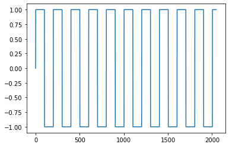

```python
N = 2048
sr = 44100
t = np.arange(N)/sr
x = np.sign(np.sin(2*np.pi*220*t))
plt.plot(x)
```

```
array([0., 0., 0., ..., 0., 0., 0.])
```

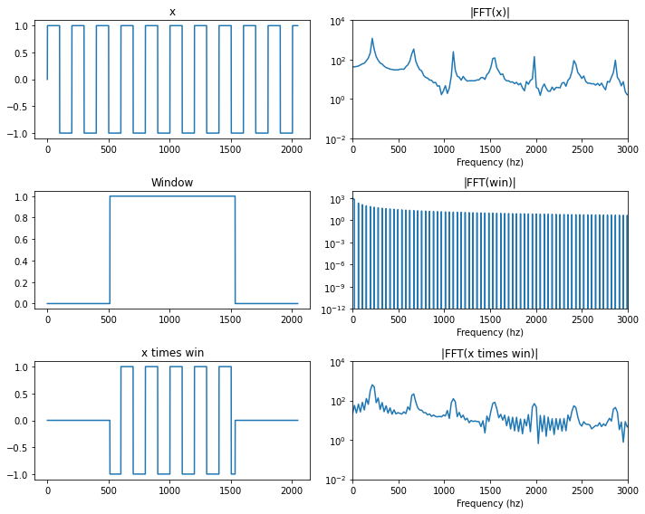

```python
plot_dft_window(x, lambda N: np.ones(N), sr)
```

## Square Wave with Sine Window

This is a huge improvement over the square window, because the side lobes have much lower magnitude in the frequency response of the window

```
array([0., 0., 0., ..., 0., 0., 0.])
```

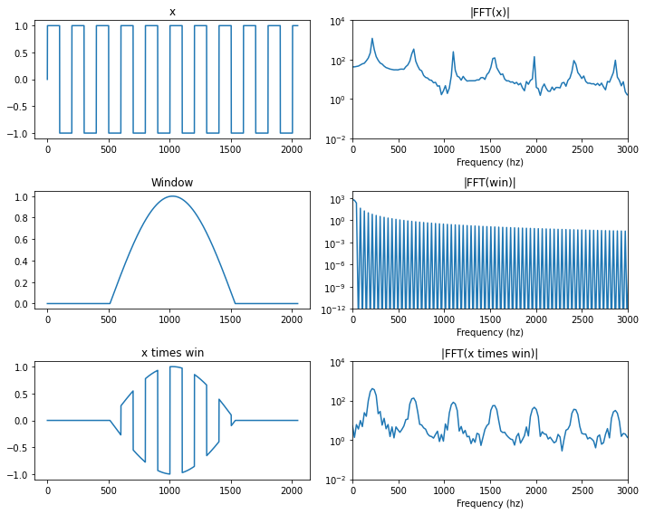

```python
plot_dft_window(x, sin_window, sr)
```

## Square Wave with Hann Window

The side lobes are lower here than they are in the sine window!

```
array([0., 0., 0., ..., 0., 0., 0.])
```

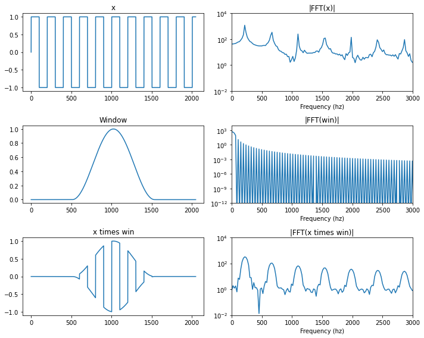

```python
plot_dft_window(x, hann_window, sr)
```

## Square Wave with Blackman-Harris Window

The side lobes are very low in this window, but it does blur the peaks a little bit

```
array([0., 0., 0., ..., 0., 0., 0.])
```

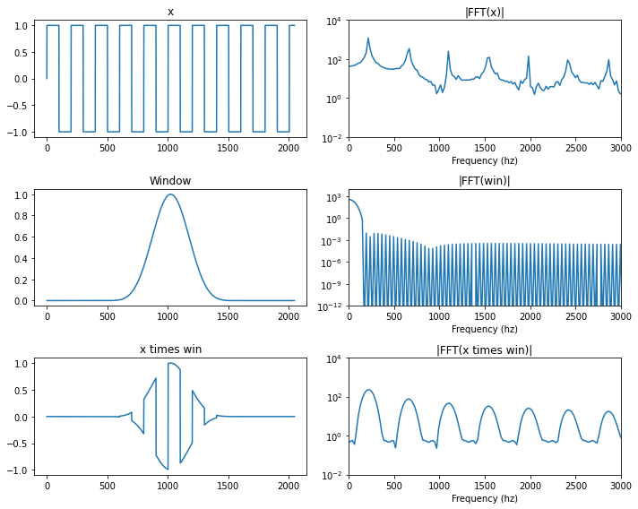

```python
plot_dft_window(x, blackman_harris_window, sr)
```